# Mini-Tutorial 3

Shane Hauck

3/7/2022

**Mini-Tutorial 3: Expressing Uncertainty**

The goal of this section is to generally show how graphs that express variability are typically better than graphs that show no variability whatsoever. Graphs that show no variability can be misleading to viewers as it might tell a skewed story. It is important that as creators of graphs we reveal all information that we have that makes the data and our findings what it is.

In this example, I will be using this dataset featuring the top 100 NFL salarys in each position on given years. The variables of interest are:

- year
- Cornerback
- Defensive Lineman
- Linebacker
- Offensive Lineman
- Quarterback
- Running Back
- Safety
- Special Teamer
- Tight End
- Wide Receiver

```r
library(tidyverse)
nfl_salary <- read_csv("data/nfl_salary.csv")
nfl_salary
```

```
## # A tibble: 800 x 11
##     year Cornerback `Defensive Lineman` Linebacker `Offensive Linem~ Quarterback
##    <dbl>      <dbl>               <dbl>      <dbl>             <dbl>       <dbl>
##  1  2011   11265916            17818000   16420000          15960000    17228125
##  2  2011   11000000            16200000   15623000          12800000    16000000
##  3  2011   10000000            12476000   11825000          11767500    14400000
##  4  2011   10000000            11904706   10083333          10358200    14100000
##  5  2011   10000000            11762782   10020000          10000000    13510000
##  6  2011    9244117            11340000    8150000           9859166    13250000
##  7  2011    8000000            10000000    7812500           9500000    12950000
##  8  2011    7900000             9482500    7700000           9420000    12574700
##  9  2011    7400000             8450000    7200000           8880000    12465000
## 10  2011    7000000             8383266    7100000           8686750    11320000
## # ... with 790 more rows, and 5 more variables: Running Back <dbl>,
## #   Safety <dbl>, Special Teamer <dbl>, Tight End <dbl>, Wide Receiver <dbl>
```

First, I am going to show an example of a graph you should NOT make. The graph will be a bar plot showing the average salary per position.

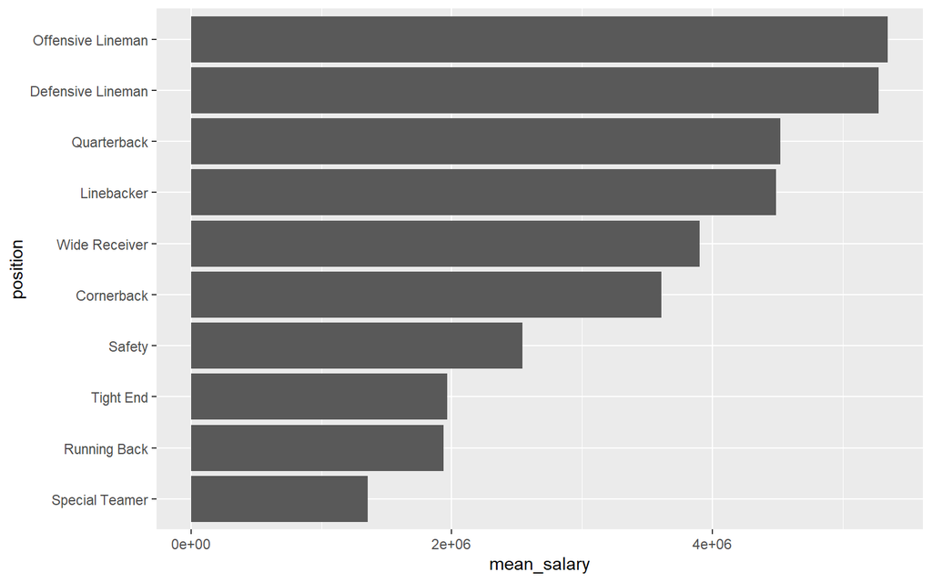

```r
plot1 <- nfl_salary %>% pivot_longer(cols = c(2:11), names_to = "position", values_to = "salary") %>%
  filter(is.na(salary) == FALSE) %>%
  group_by(position) %>%
  summarise(mean_salary = mean(salary)) %>%
  mutate(position = fct_reorder(position, mean_salary))
ggplot(plot1, aes(x = position, y = mean_salary)) +
  geom_col() +
  coord_flip()
```

To do this, we are going to make a point plot where all points in the data will be shown. We will fade the data points so the data points that overlap with each other will be darker showing a greater total number of players that have that salary. To continue to show the mean for each position, we will add a red dot that will represent the mean salary.

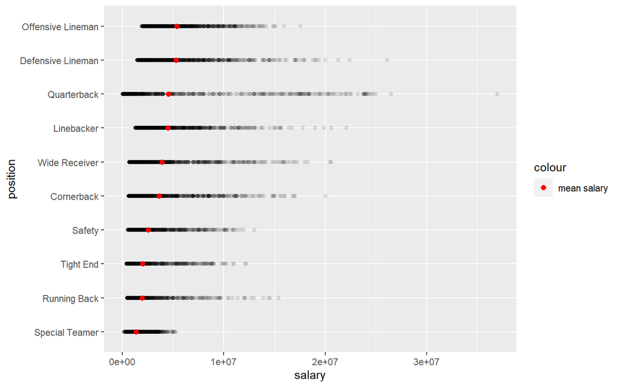

```r
plot2 <- nfl_salary %>% pivot_longer(cols = c(2:11), names_to = "position", values_to = "salary") %>%
  filter(is.na(salary) == FALSE) %>%
  group_by(position) %>%
  mutate(mean_salary = mean(salary)) %>%
  ungroup() %>%
  mutate(position = fct_reorder(position, mean_salary))
ggplot(plot2, aes(x = position, y = salary)) +
  geom_point(alpha = 0.1) +
  geom_point(aes(y = mean_salary, colour = "mean salary"), size = 2) +
  coord_flip() +
  scale_colour_manual(values = c("mean salary" = "red"))
```

This graph is now a much better representation of the variability in dataset. You can now see that according to the data, lineman never get small amounts of money where as most other positions have players getting smaller values. You can now see that Quarterbacks for example, have players making a lot more money than the average but their average is dragged down by a large amount of players getting payed small amounts.

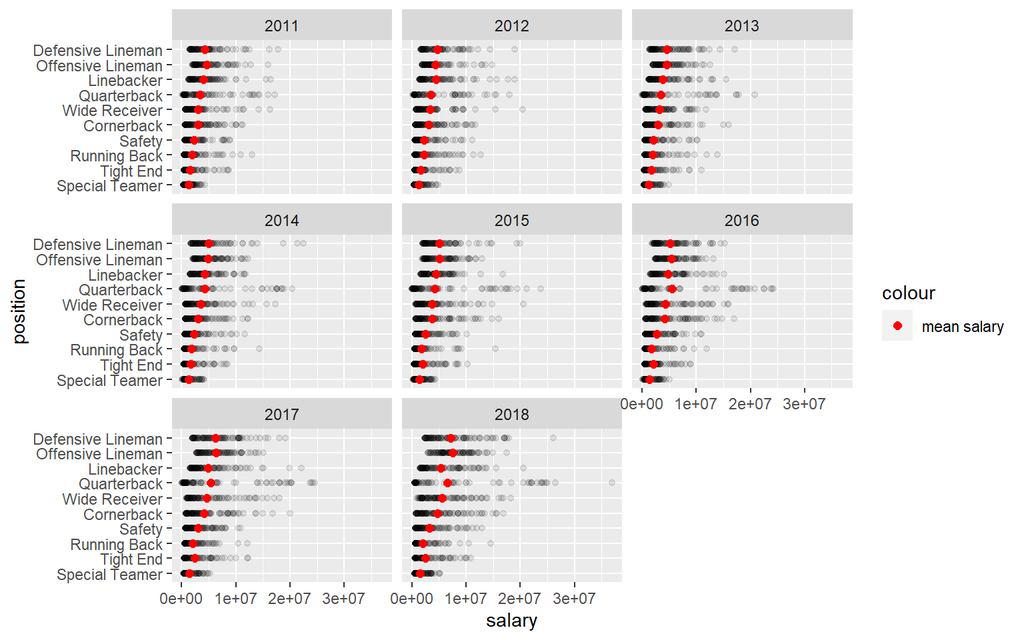

```r
plot3 <- nfl_salary %>% pivot_longer(cols = c(2:11), names_to = "position", values_to = "salary") %>%
  filter(is.na(salary) == FALSE) %>%
  group_by(position, year) %>%
  mutate(mean_salary = mean(salary)) %>%
  ungroup() %>%
  mutate(position = fct_reorder(position, mean_salary))

ggplot(plot3, aes(x = position, y = salary)) +
  geom_point(alpha = 0.1) +
  geom_point(aes(y = mean_salary, colour = "mean salary"), size = 2) +
  coord_flip() +
  scale_colour_manual(values = c("mean salary" = "red")) +
  facet_wrap(~year)
```

Since this dataset is so large and features so many points in the same areas, I feel that the faceted graph better shows certain trends in different years for the positions. You could likely argue that this is overkill but if the goal is to tell the whole story of the data, it is better to over-show the variability than under-show the variability..